# Analisis mortalidad por causas 9

##### 1.12.5.1 Area de interes

Detectar areas de interes.

```r
# hacer mas eficiente
prob2 <- geo_subset2 |>
  mutate(
    pmap.prob = ifelse(rr > 1 & pmap < 0.05,
                       1,
                       0)
    ) |>
  group_by(pmap.prob) |>
  summarise() |>
  filter(pmap.prob == 1)
```

Se seleccionan aquellas areas con SMR mayor que uno (sobre mortalidad) y una probabilidad (umbral) menor a 0.05.

```r
head(prob2)
```

```
## Simple feature collection with 1 feature and 1 field
## Geometry type: MULTIPOLYGON
## Dimension:     XY
## Bounding box:  xmin: -68.60841 ymin: -38.99276 xmax: -54.14654 ymax: -21.99754
## Geodetic CRS:  WGS 84
## # A tibble: 1 × 2
##   pmap.prob                                                                 geom
##       <dbl>                                                   <MULTIPOLYGON [°]>
## 1         1 (((-65.23716 -26.86339, -65.23716 -26.86303, -65.23711 -26.86282, -…
```

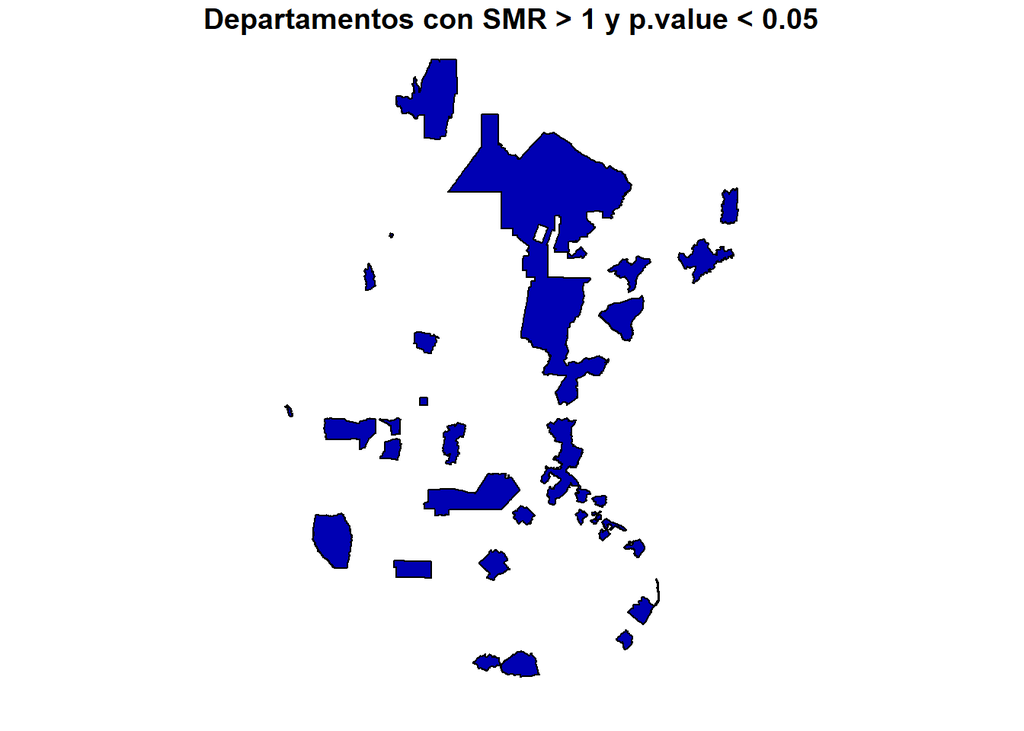

```r
plot(prob2, main = "Departamentos con SMR > 1 y p.value < 0.05")
```

Se resalta el cluster de sobremortalidad sobre el mapa original de SMR

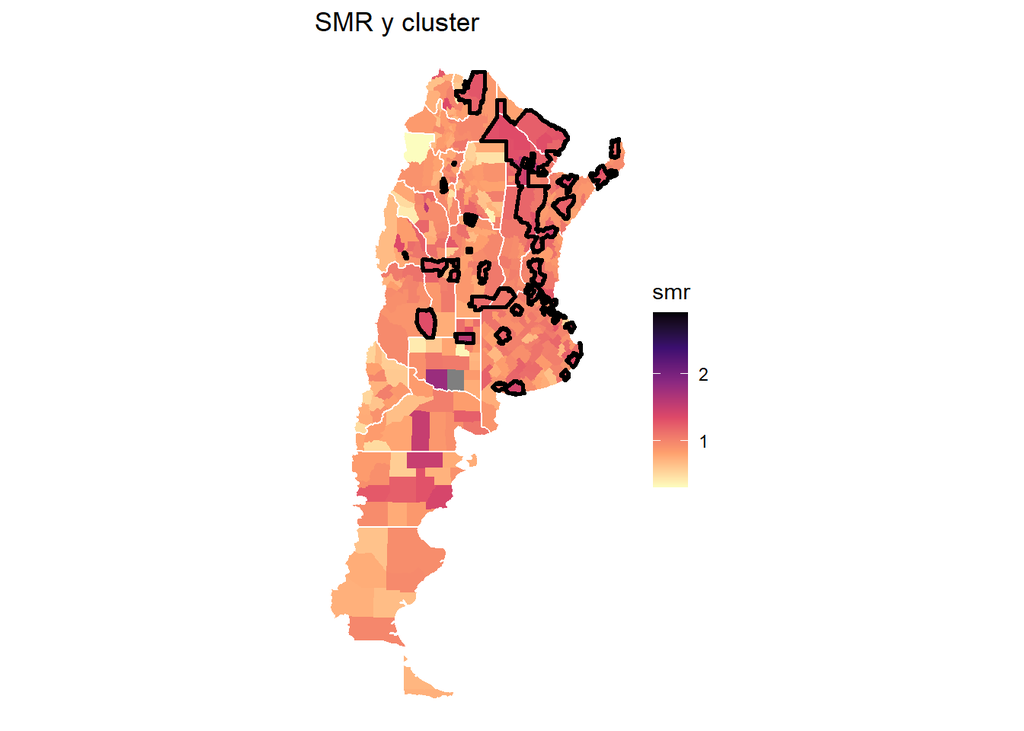

```r
geo_subset2 |>
  ggplot()+
  geom_sf(data = geo_subset2, aes(fill=smr), color=NA)+
  scale_fill_viridis_c(option = "magma", direction = -1)+
  geom_sf(data = geo_prov, fill=NA, lwd=.5, color="white" )+
  geom_sf(data = prob2, color="black",lwd=1, alpha=0)+
  coord_sf(crs = 4326)+
  labs(
    title= "SMR y cluster"
  )+
  theme_void()
```

Se observa claramente un area en gran parte de la region NEA, pero tambien se detectan mas areas de interes en el resto del pais, norte de PBA y algunos partidos del sur, Entre Ríos, Cordoba…

Al observar Cordoba se detecta a Sobremonte, un departamento del norte donde se sabe es un valor atipico debido a la baja poblacion. En adelante, se construye otro mapa, con suavizado local.

##### 1.12.5.2 Suavizado Bayes Local

1.12.5.2.0.1 Bayesiano empirico

Modelos bayesiano empirico, con dependencia espacial

```r
eb_subset2 <- EBlocal(
  ri = geo_subset2$casos,
  ni = geo_subset2$pob,
  nb = nb_gal,
  zero.policy = TRUE
)
```

```r
str(eb_subset2)
```

```
## 'data.frame':    511 obs. of  2 variables:
##  $ raw: num  0.01887 0.00773 0.00879 0.00366 0.0107 ...
##  $ est: num  0.0129 0.0118 0.0109 0.0115 0.0114 ...
##  - attr(*, "parameters")=List of 2
##   ..$ a: num [1:511] 2.59e-06 7.65e-08 8.29e-07 3.36e-06 1.50e-06 ...
##   ..$ m: num [1:511] 0.0109 0.0119 0.0116 0.0127 0.0121 ...
```

```r
geo_subset2$raw <- eb_subset2$raw
geo_subset2$est <- eb_subset2$est
```

```r
ggplot()+
  geom_sf(data = geo_subset2, aes(fill=est), color=NA)+
  scale_fill_viridis_c(option = "magma", direction = -1)+
  geom_sf(data = geo_prov, fill=NA, lwd=.5, color="white")+
  coord_sf(crs = 4326)+
  labs(
    title = "Suavizado Bayes empirico",
    fill="RM suavizado"
  )+
  theme_void()-> mapa_eb_v25
```

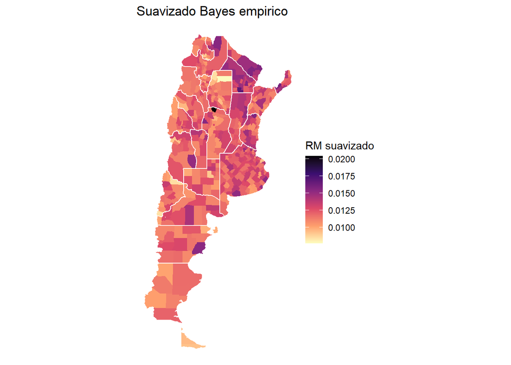

```r
mapa_eb_v25
```

Comparacion de mapa con la razon bruta

```r
geo_data_mort_estandar |>
  filter(gedad == "25 a 69",
         grupo_oms=="Enfermedades no transmisibles",
         sexo == "Varon") |>
  ggplot(aes(fill=rm_loc))+
  coord_sf(crs = 4326)+
  geom_sf(color=NA)+
  scale_fill_viridis_c(option = "magma", direction = -1)+
  geom_sf(data = geo_prov, fill=NA, lwd=.5, color="white")+
  labs(
    title="Rm cruda"
  )+
  theme_void() -> mapa_raw_v25
```

[output not shown]

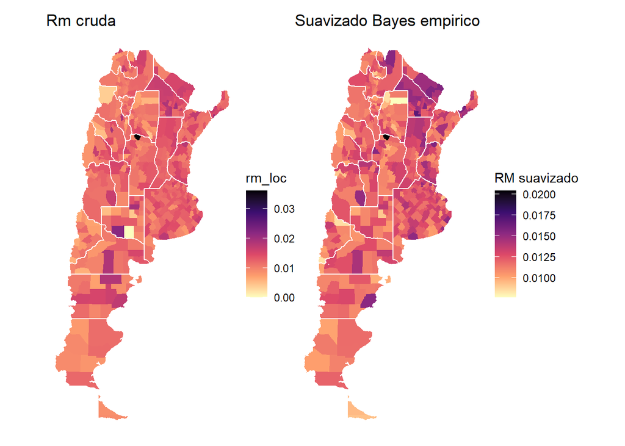

```r
mapa_raw_v25 | mapa_eb_v25
```

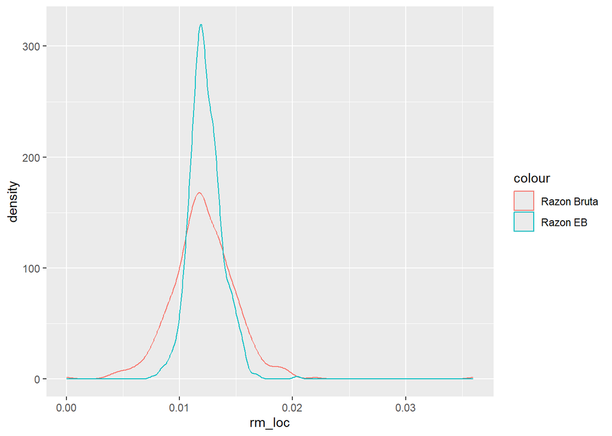

```r
geo_subset2 |>
  st_drop_geometry() |>
  ggplot()+
  geom_density(aes(rm_loc, color="Razon Bruta"))+
  geom_density(aes(est, color="Razon EB"))
```

```r
geo_subset2 |>
  st_drop_geometry() |>
  filter(label == "Sobremonte") |>
  select(casos, pob, casos_esp, rm_loc, rm, smr, pmap) |>
  mutate(pmap = format(round(pmap,10),nsmall=10))
```

```
##   casos  pob casos_esp     rm_loc         rm  smr    pmap
## 1    43 1195     14.72 0.03598326 0.01232034 2.92 1.7e-09
```

```r
anios2 <- c(anios, 2021)
anios2
```

```
## [1] 2006 2009 2012 2015 2018 2021
```

```r
label_anios2 <- c(label_anios, "2020-2022")
```

```r
data_mort_estandar |>
  filter(
    sexo == "Varon",
    gedad == "25 a 69",
    label == "Sobremonte",
    grupo_oms == "Enfermedades no transmisibles"
    # anio %in% c(2006, 2018, 2021)
  ) |>
  select(anio, grupo_oms, casos, pob, casos_esp, rm_loc, rm, smr) |>
  arrange(anio, grupo_oms)->subset_sobremonte
```

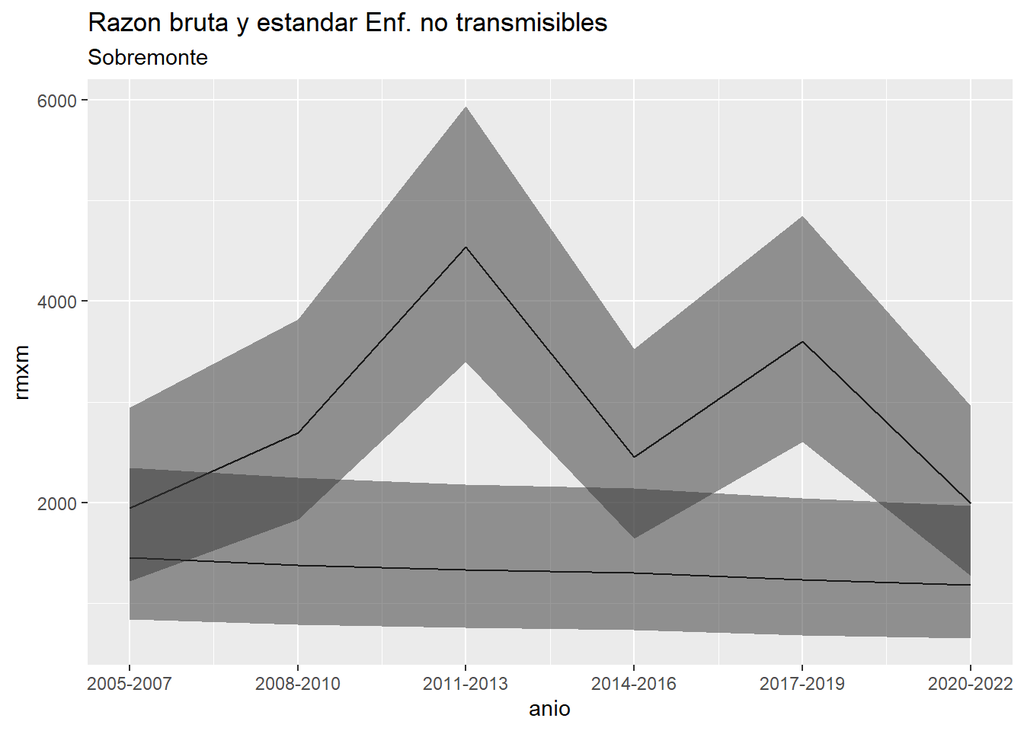

```r
subset_sobremonte |>
  mutate(
    rmxm = rm_loc * 100000,
    rmxm_est = rm * 100000,
    ici_rmxm = round(qchisq(0.025, 2 * casos) / (2 * pob) * 100000,1), #intervalo inferior
    ics_rmxm = round(qchisq(0.975, 2 * casos + 2) / (2 * pob) * 100000,1), # intervalo superior
    ici_rmxm_est = round(qchisq(0.025, 2 * casos_esp) / (2 * pob) * 100000,1), #intervalo inferior
    ics_rmxm_est = round(qchisq(0.975, 2 * casos_esp + 2) / (2 * pob) * 100000,1) # intervalo superior
  ) |>
  ggplot()+
  geom_line(aes(anio, rmxm))+
  geom_line(aes(anio, rmxm_est))+
  geom_ribbon(aes(anio, ymin = ici_rmxm, ymax = ics_rmxm), alpha=.5)+
  geom_ribbon(aes(anio, ymin = ici_rmxm_est, ymax = ics_rmxm_est), alpha=.5)+
  scale_x_continuous(breaks = anios2, labels = label_anios2)+
  labs(
    title = "Razon bruta y estandar Enf. no transmisibles",
    subtitle = "Sobremonte"
  )
```

el pmap = 1.7E-9 = 0.0000000017

#### 1.12.6 Bayes espacial 3

Comparacion con 2015

El ejemplo anterior muestra que con el suavizamiento , o “estrechamiento” de la distribucion (“shrunk”) funciono como se esperaba para diferenciar ruido de señal. Es decir, se desestimaron en el analisis ciertas areas, y el mapa final muestra las areas de sobremortalidad. Aunque esto era previsible dadas las grandes diferencias en el patron de mortalidad en este grupo de edad y causa.  
En adelante se pone a prueba el mismo procedimiento pero para una distribucion por causas mas aplanada, y sin grandes diferencias evidentes.

Mortalidad de varones en edades centrales 25 a 69 por Enfermedades no transmisibles.

```r
subset3 <- data_mort_estandar |>
  filter(
    gedad == "25 a 69",
    anio == 2015,
    sexo == "Varon",
    grupo_oms == "Enfermedades no transmisibles"
  )
```

probabilidad de exceso de mortalidad

```r
probmap_subset3 <- spdep::probmap(
  n = subset3$casos, x = subset3$pob,
  row.names = subset3$geocodigo,
  alternative = "greater"
)
```

```r
head(probmap_subset3)
```

```
##              raw  expCount  relRisk        pmap
## 14154 0.02453469 15.438237 187.8453 0.001314582
## 58098 0.02418097 16.744348 185.1371 0.001151721
## 26063 0.02409639  3.252217 184.4895 0.111446736
## 26070 0.02245250  7.562385 171.9034 0.044990541
## 6336  0.02209945 14.184370 169.2003 0.010772067
## 66105 0.02129222 17.789237 163.0199 0.008905159
```

Se observan valores mas extremos que en el caso anterior.

```r
subset3$rm_loc2 <- probmap_subset3$raw
subset3$casos_exp <- probmap_subset3$expCount
subset3$rr <- probmap_subset3$relRisk / 100
subset3$pmap <- probmap_subset3$pmap
```

```r
subset3 |>
  merge(geo_depto, by.x = "geocodigo", by.y = "DEPTO_LINK")-> geo_subset3
geo_subset3 <- st_as_sf(geo_subset3)
```

Mapas

```r
geo_subset3 |>
  ggplot(aes(fill=smr))+
  geom_sf(color=NA)+
  scale_fill_viridis_c(option = "magma", direction = -1)+
  geom_sf(data = geo_prov, fill=NA, lwd=.5, color="white")+
  labs(
    title="SMR"
  )+
  theme_void()-> mapa_smr_v25_2

geo_subset3 |>
  ggplot(aes(fill=pmap))+
  geom_sf(color=NA)+
  scale_fill_viridis_c(option = "D" , direction = -1)+
  geom_sf(data = geo_prov, fill=NA, lwd=.5, color="white")+
  labs(
    title = "Prob"
  )+
  theme_void()-> mapa_pmap_v25_2
```

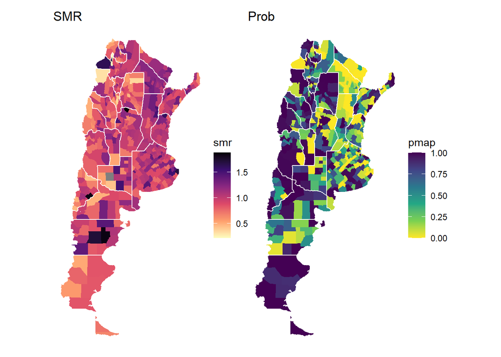

```r
mapa_smr_v25_2 | mapa_pmap_v25_2
```

##### 1.12.6.1 Area de interes

Detectar areas de interes.

```r
# hacer mas eficiente
prob3 <- geo_subset3 |>
  mutate(
    pmap.prob = ifelse(rr > 1 & pmap < 0.05,
                       1,
                       0)
    ) |>
  group_by(pmap.prob) |>
  summarise() |>
  filter(pmap.prob == 1)
```

Se seleccionan aquellas areas con SMR mayor que uno (sobre mortalidad) y una probabilidad (umbral) menor a 0.05.

```r
head(prob3)
```

```
## Simple feature collection with 1 feature and 1 field
## Geometry type: MULTIPOLYGON
## Dimension:     XY
## Bounding box:  xmin: -72.07028 ymin: -46.00524 xmax: -54.14654 ymax: -22.48389
## Geodetic CRS:  WGS 84
## # A tibble: 1 × 2
##   pmap.prob                                                                 geom
##       <dbl>                                                   <MULTIPOLYGON [°]>
## 1         1 (((-64.35585 -23.51812, -64.31195 -23.51823, -64.26097 -23.51837, -…
```

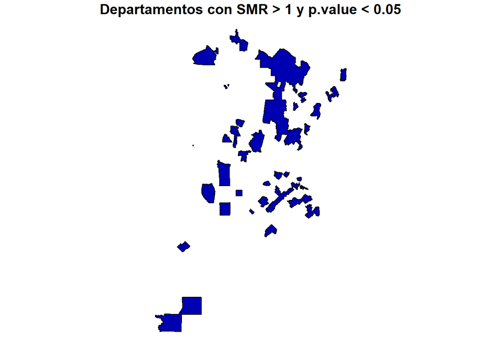

```r
plot(prob3, main = "Departamentos con SMR > 1 y p.value < 0.05")
```

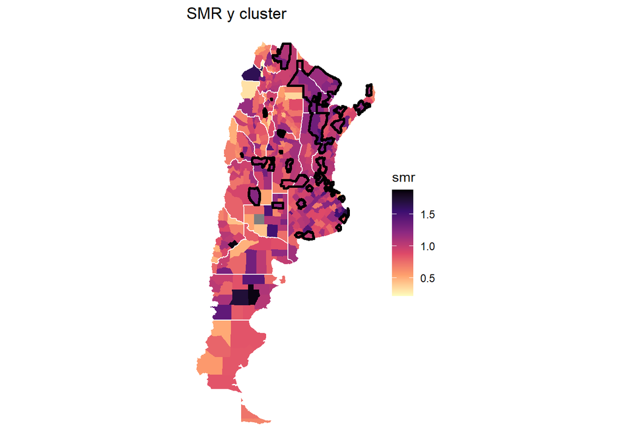

```r
geo_subset3 |>
  ggplot()+
  geom_sf(data = geo_subset3, aes(fill=smr), color=NA)+
  scale_fill_viridis_c(option = "magma", direction = -1)+
  geom_sf(data = geo_prov, fill=NA, lwd=.5, color="white" )+
  geom_sf(data = prob2, color="black",lwd=1, alpha=0)+
  coord_sf(crs = 4326)+
  labs(
    title= "SMR y cluster"
  )+
  theme_void()
```

Al observar Cordoba se detecta a Sobremonte, un departamento del norte donde se sabe es un valor atipico debido a la baja poblacion. En adelante, se construye otro mapa, con suavizado local.

##### 1.12.6.2 Suavizado Bayes Local

1.12.6.2.0.1 Bayesiano empirico

Modelos bayesiano empirico, con dependencia espacial

```r
eb_subset3 <- EBlocal(
  ri = geo_subset3$casos,
  ni = geo_subset3$pob,
  nb = nb_gal,
  zero.policy = TRUE
)
```

```r
str(eb_subset3)
```

```
## 'data.frame':    511 obs. of  2 variables:
##  $ raw: num  0.01603 0.00472 0.01259 0.00399 0.00991 ...
##  $ est: num  0.0125 0.013 0.0128 0.013 0.0113 ...
##  - attr(*, "parameters")=List of 2
##   ..$ a: num [1:511] 1.89e-06 4.49e-07 9.16e-07 1.52e-06 1.45e-06 ...
##   ..$ m: num [1:511] 0.0117 0.0132 0.0128 0.0135 0.0126 ...
```

```r
geo_subset3$raw <- eb_subset3$raw
geo_subset3$est <- eb_subset3$est
```

```r
ggplot()+
  geom_sf(data = geo_subset3, aes(fill=est), color=NA)+
  scale_fill_viridis_c(option = "magma", direction = -1)+
  geom_sf(data = geo_prov, fill=NA, lwd=.5, color="white")+
  coord_sf(crs = 4326)+
  labs(
    title = "Suavizado Bayes empirico",
    fill="RM suavizado"
  )+
  theme_void()-> mapa_eb_v25_2
```

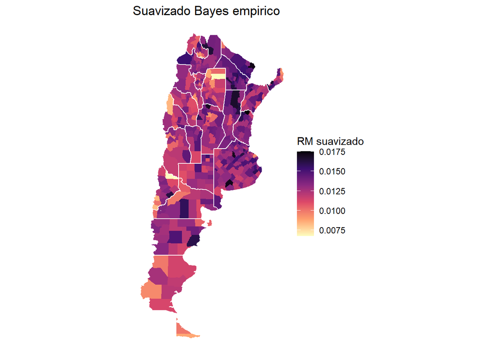

```r
mapa_eb_v25_2
```

```r
# geo_data_mort_estandar |>
#   filter(gedad == "25 a 69",
#          grupo_oms=="Enfermedades no transmisibles",
#          sexo == "Varon") |>
#   ggplot(aes(fill=rm_loc))+
#   coord_sf(crs = 4326)+
#   geom_sf(color=NA)+
#   scale_fill_viridis_c(option = "magma", direction = -1)+
#   geom_sf(data = geo_prov, fill=NA, lwd=.5, color="white")+
#   labs(
#     title="Rm cruda"
#   )+
#   theme_void() -> mapa_raw_v25_2
```

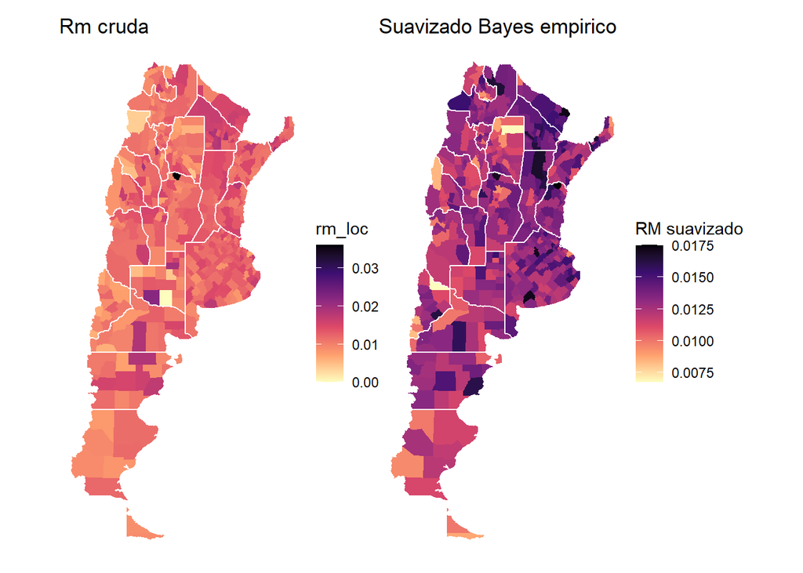

```r
mapa_raw_v25 | mapa_eb_v25_2
```

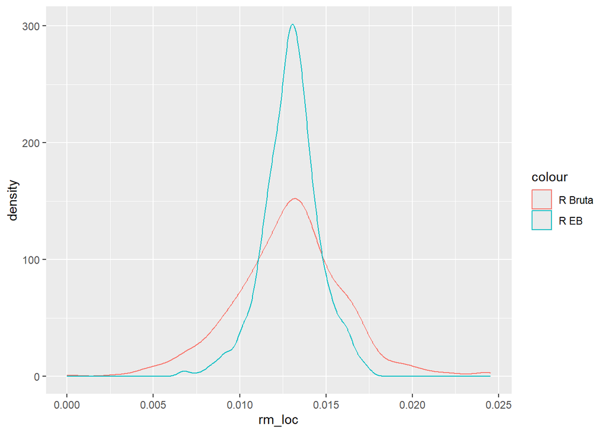

```r
geo_subset3 |>
  st_drop_geometry() |>
  ggplot()+
  geom_density(aes(rm_loc, color="R Bruta"))+
  geom_density(aes(est, color="R EB"))
```

### 1.13 Conclusiones

En conclusiones parciales se sostiene que:

Existe la posibilidad de suavizar (domar) los valores extremos derivados de escazes de datos.  
Se estima conveniente hacer lo mismo, con una correcta evaluacion de la calidad de datos (dado que una alta frecuencia de mal definidas, puede conducir a subestimar la mortalidad por ciertas causas. ej caso de Sgo del Estero).

Aun cuando los casos extremos son conservados, al estrecharse la distirbucion, resaltan las areas relevantes, que desde el enfoque porpuesto se cnetraron en la probabilidad de presentar sobremortalidad.

Se estima necesario, corregir la poblacion de referencia o que determina el estandar, quiza mediante modelos jerarquicos, o limitando las matrices de contiguidad. (esto ultimo resulta interesante desde el analisis geografico debido fronteras fisicas, que no son consideradas cuandos se analizan simplemente poligonos).

el sesgo deriva de la sobrerepresentacion del total nacioanl por parte de las ciudades de la region centro, Caba, Gran Bs As, Cordoba, Rosario y Tucuman. se trata ademas de unidades de area muy urbanizadas y con estructuras por edad mas envejecidas.

Se sostiene la relevancia de los analisis multiescalares, en cuanto una provincia puede contener diferencias en los niveles de mortalidad que justifican el analisis geografico, pero no permiten alcanzar conclusiones parciales sin considerar las diferencias geograficas en todos los niveles.

no se aprevian grandes variaciones en el tiempo, salvo casos criticos ya mencionados. esto permitiria agregar temporalmente los datos a fines de obtener modelos mas robustos.

algunas areas geograficas podrian agregarse, sin todavia haber definido un criterio claro por el cual determinar este proceso. Algunas unidades de area, de la region cuyo, patagonia son en extremo bajos en poblacion (o la poblacion es muy variable) y variacion en la frecuencia de casos pueden derivar en estimaciones sesgadas.

Resulta interesante clasificar las unidades de area, distinguiendo aquellas donde la pobacion y las ciudades son mas grandes, de unidades de area intermedias, o con poblacion dispersa, y mas o menos rurales, etc. Esto es relavante en la medida que ciertas areas distantes, puede compartir caracteres geograficos (o en el patron de habitat y estructuras por edad y sexo) similares (no por ello faltan al principio de Tobler basado en la contiguidad para la detemrinacion de areas “proximas”).

En cuanto a los grupos de edad, ya que se puede extender el marco temporal, podrian desagregarse grupos de edad. Al tiempo que resulta relevante que se pueda distinguir la mortalidad infantil (0 y 1 a 5 años) considerando que es este factor el que conduce el patron en el grupo 0-24. Ademas se puede corregir la estimacion de la mortalidad en 0 años por nacimientos y no la interpolacion de población.

En cuanto a la poblacion no ha mostrado variaciones el analisis de acuerdo a cambios en el input de las rondas censales, sin embargo se considera conveniente un capitulo previo donde la poblaciones por unidades de area sean analizadas cuidadosamente. sobre todo a los fines de determinar, flujo migratorios, subestimacion de grupos especificos, y la posibilidad de agregar areas.

En capitulos siguientes, se ensayaran metodos para realizar las estimaciones para todo el conjunto de datos.en lugar de la construccion de casos.

Se prueban diferentes matrices de contiguidad (queen1, queen2, Weighted, etc.). y los resultados obtenidos.

Se reflexiona sobre el efecto de borde o frontera (edge effect) derivado de no considerar las unidades de area de paises vecinos, donde se espera los extremos nacionales sean menos evidnetes, y las transiciones (en ref a las variaciones geograficas) sean mas suaves.

se compararan resultados a fines de detectar sesgos como el suavizamiento (estrechamiento) excesivo.